# Optimal Treatment Analysis

## Outcome Variable

**Outcome Variable:** ever_stunted

## Predictor Variables

**Intervention Variable:** impsan

**Adjustment Set:**

- arm
- sex
- W_mage
- meducyrs
- feducyrs
- hhwealth_quart
- hfoodsec
- W_mhtcm
- W_nrooms
- W_nchldlt5
- W_parity
- impfloor
- safeh20
- delta_W_mage
- delta_meducyrs
- delta_feducyrs
- delta_hhwealth_quart
- delta_hfoodsec
- delta_W_mhtcm
- delta_W_nrooms
- delta_W_nchldlt5
- delta_W_parity
- delta_impfloor
- delta_safeh20

## Stratifying Variables

The analysis was stratified on these variable(s):

- agecat
- studyid
- country

## Data Summary

| agecat | studyid | country | impsan | ever_stunted | n_cell | n |
| --- | --- | --- | --- | --- | --- | --- |
| 0-24 months (no birth st.) | ki0047075b-MAL-ED | BANGLADESH | 1 | 0 | 83 | 203 |
| 0-24 months (no birth st.) | ki0047075b-MAL-ED | BANGLADESH | 1 | 1 | 87 | 203 |
| 0-24 months (no birth st.) | ki0047075b-MAL-ED | BANGLADESH | 0 | 0 | 11 | 203 |
| 0-24 months (no birth st.) | ki0047075b-MAL-ED | BANGLADESH | 0 | 1 | 22 | 203 |
| 0-24 months (no birth st.) | ki0047075b-MAL-ED | BRAZIL | 1 | 0 | 157 | 189 |
| 0-24 months (no birth st.) | ki0047075b-MAL-ED | BRAZIL | 1 | 1 | 28 | 189 |
| 0-24 months (no birth st.) | ki0047075b-MAL-ED | BRAZIL | 0 | 0 | 4 | 189 |
| 0-24 months (no birth st.) | ki0047075b-MAL-ED | BRAZIL | 0 | 1 | 0 | 189 |
| 0-24 months (no birth st.) | ki0047075b-MAL-ED | INDIA | 1 | 0 | 45 | 195 |
| 0-24 months (no birth st.) | ki0047075b-MAL-ED | INDIA | 1 | 1 | 43 | 195 |
| 0-24 months (no birth st.) | ki0047075b-MAL-ED | INDIA | 0 | 0 | 46 | 195 |
| 0-24 months (no birth st.) | ki0047075b-MAL-ED | INDIA | 0 | 1 | 61 | 195 |
| 0-24 months (no birth st.) | ki0047075b-MAL-ED | NEPAL | 1 | 0 | 154 | 209 |
| 0-24 months (no birth st.) | ki0047075b-MAL-ED | NEPAL | 1 | 1 | 54 | 209 |
| 0-24 months (no birth st.) | ki0047075b-MAL-ED | NEPAL | 0 | 0 | 1 | 209 |
| 0-24 months (no birth st.) | ki0047075b-MAL-ED | NEPAL | 0 | 1 | 0 | 209 |
| 0-24 months (no birth st.) | ki0047075b-MAL-ED | PERU | 1 | 0 | 26 | 231 |
| 0-24 months (no birth st.) | ki0047075b-MAL-ED | PERU | 1 | 1 | 31 | 231 |
| 0-24 months (no birth st.) | ki0047075b-MAL-ED | PERU | 0 | 0 | 63 | 231 |
| 0-24 months (no birth st.) | ki0047075b-MAL-ED | PERU | 0 | 1 | 111 | 231 |
| 0-24 months (no birth st.) | ki0047075b-MAL-ED | SOUTH AFRICA | 1 | 0 | 3 | 227 |
| 0-24 months (no birth st.) | ki0047075b-MAL-ED | SOUTH AFRICA | 1 | 1 | 1 | 227 |
| 0-24 months (no birth st.) | ki0047075b-MAL-ED | SOUTH AFRICA | 0 | 0 | 96 | 227 |
| 0-24 months (no birth st.) | ki0047075b-MAL-ED | SOUTH AFRICA | 0 | 1 | 127 | 227 |
| 0-24 months (no birth st.) | ki0047075b-MAL-ED | TANZANIA, UNITED REPUBLIC OF | 1 | 0 | 0 | 202 |
| 0-24 months (no birth st.) | ki0047075b-MAL-ED | TANZANIA, UNITED REPUBLIC OF | 1 | 1 | 0 | 202 |
| 0-24 months (no birth st.) | ki0047075b-MAL-ED | TANZANIA, UNITED REPUBLIC OF | 0 | 0 | 31 | 202 |
| 0-24 months (no birth st.) | ki0047075b-MAL-ED | TANZANIA, UNITED REPUBLIC OF | 0 | 1 | 171 | 202 |
| 0-24 months (no birth st.) | ki1017093-NIH-Birth | BANGLADESH | 1 | 0 | 92 | 530 |
| 0-24 months (no birth st.) | ki1017093-NIH-Birth | BANGLADESH | 1 | 1 | 111 | 530 |

[output cut: 174 more lines]

The following strata were considered:

- agecat: 0-24 months (no birth st.), studyid: ki0047075b-MAL-ED, country: BANGLADESH
- agecat: 0-24 months (no birth st.), studyid: ki0047075b-MAL-ED, country: BRAZIL
- agecat: 0-24 months (no birth st.), studyid: ki0047075b-MAL-ED, country: INDIA
- agecat: 0-24 months (no birth st.), studyid: ki0047075b-MAL-ED, country: NEPAL
- agecat: 0-24 months (no birth st.), studyid: ki0047075b-MAL-ED, country: PERU
- agecat: 0-24 months (no birth st.), studyid: ki0047075b-MAL-ED, country: SOUTH AFRICA
- agecat: 0-24 months (no birth st.), studyid: ki0047075b-MAL-ED, country: TANZANIA, UNITED REPUBLIC OF
- agecat: 0-24 months (no birth st.), studyid: ki1017093-NIH-Birth, country: BANGLADESH
- agecat: 0-24 months (no birth st.), studyid: ki1017093b-PROVIDE, country: BANGLADESH
- agecat: 0-24 months (no birth st.), studyid: ki1017093c-NIH-Crypto, country: BANGLADESH
- agecat: 0-24 months (no birth st.), studyid: ki1114097-CONTENT, country: PERU
- agecat: 0-24 months (no birth st.), studyid: ki1135781-COHORTS, country: GUATEMALA
- agecat: 0-24 months (no birth st.), studyid: ki1135781-COHORTS, country: INDIA
- agecat: 0-24 months (no birth st.), studyid: ki1135781-COHORTS, country: PHILIPPINES
- agecat: 0-24 months (no birth st.), studyid: ki1148112-LCNI-5, country: MALAWI
- agecat: 0-24 months (no birth st.), studyid: kiGH5241-JiVitA-3, country: BANGLADESH
- agecat: 0-24 months (no birth st.), studyid: kiGH5241-JiVitA-4, country: BANGLADESH
- agecat: 0-6 months (no birth st.), studyid: ki0047075b-MAL-ED, country: BANGLADESH
- agecat: 0-6 months (no birth st.), studyid: ki0047075b-MAL-ED, country: BRAZIL
- agecat: 0-6 months (no birth st.), studyid: ki0047075b-MAL-ED, country: INDIA
- agecat: 0-6 months (no birth st.), studyid: ki0047075b-MAL-ED, country: NEPAL
- agecat: 0-6 months (no birth st.), studyid: ki0047075b-MAL-ED, country: PERU
- agecat: 0-6 months (no birth st.), studyid: ki0047075b-MAL-ED, country: SOUTH AFRICA
- agecat: 0-6 months (no birth st.), studyid: ki0047075b-MAL-ED, country: TANZANIA, UNITED REPUBLIC OF
- agecat: 0-6 months (no birth st.), studyid: ki1017093-NIH-Birth, country: BANGLADESH
- agecat: 0-6 months (no birth st.), studyid: ki1017093b-PROVIDE, country: BANGLADESH
- agecat: 0-6 months (no birth st.), studyid: ki1017093c-NIH-Crypto, country: BANGLADESH
- agecat: 0-6 months (no birth st.), studyid: ki1114097-CONTENT, country: PERU
- agecat: 0-6 months (no birth st.), studyid: ki1135781-COHORTS, country: GUATEMALA
- agecat: 0-6 months (no birth st.), studyid: ki1135781-COHORTS, country: INDIA
- agecat: 0-6 months (no birth st.), studyid: ki1135781-COHORTS, country: PHILIPPINES
- agecat: 0-6 months (no birth st.), studyid: ki1148112-LCNI-5, country: MALAWI
- agecat: 0-6 months (no birth st.), studyid: kiGH5241-JiVitA-3, country: BANGLADESH
- agecat: 0-6 months (no birth st.), studyid: kiGH5241-JiVitA-4, country: BANGLADESH
- agecat: 6-24 months, studyid: ki0047075b-MAL-ED, country: BANGLADESH
- agecat: 6-24 months, studyid: ki0047075b-MAL-ED, country: BRAZIL
- agecat: 6-24 months, studyid: ki0047075b-MAL-ED, country: INDIA
- agecat: 6-24 months, studyid: ki0047075b-MAL-ED, country: NEPAL
- agecat: 6-24 months, studyid: ki0047075b-MAL-ED, country: PERU
- agecat: 6-24 months, studyid: ki0047075b-MAL-ED, country: SOUTH AFRICA
- agecat: 6-24 months, studyid: ki0047075b-MAL-ED, country: TANZANIA, UNITED REPUBLIC OF
- agecat: 6-24 months, studyid: ki1017093-NIH-Birth, country: BANGLADESH
- agecat: 6-24 months, studyid: ki1017093b-PROVIDE, country: BANGLADESH
- agecat: 6-24 months, studyid: ki1017093c-NIH-Crypto, country: BANGLADESH
- agecat: 6-24 months, studyid: ki1114097-CONTENT, country: PERU
- agecat: 6-24 months, studyid: ki1135781-COHORTS, country: GUATEMALA
- agecat: 6-24 months, studyid: ki1135781-COHORTS, country: INDIA
- agecat: 6-24 months, studyid: ki1135781-COHORTS, country: PHILIPPINES
- agecat: 6-24 months, studyid: ki1148112-LCNI-5, country: MALAWI
- agecat: 6-24 months, studyid: kiGH5241-JiVitA-3, country: BANGLADESH
- agecat: 6-24 months, studyid: kiGH5241-JiVitA-4, country: BANGLADESH

### Dropped Strata

Some strata were dropped due to rare outcomes:

- agecat: 0-24 months (no birth st.), studyid: ki0047075b-MAL-ED, country: BRAZIL
- agecat: 0-24 months (no birth st.), studyid: ki0047075b-MAL-ED, country: NEPAL
- agecat: 0-24 months (no birth st.), studyid: ki0047075b-MAL-ED, country: SOUTH AFRICA
- agecat: 0-24 months (no birth st.), studyid: ki0047075b-MAL-ED, country: TANZANIA, UNITED REPUBLIC OF
- agecat: 0-24 months (no birth st.), studyid: ki1148112-LCNI-5, country: MALAWI
- agecat: 0-6 months (no birth st.), studyid: ki0047075b-MAL-ED, country: BRAZIL
- agecat: 0-6 months (no birth st.), studyid: ki0047075b-MAL-ED, country: NEPAL
- agecat: 0-6 months (no birth st.), studyid: ki0047075b-MAL-ED, country: SOUTH AFRICA
- agecat: 0-6 months (no birth st.), studyid: ki0047075b-MAL-ED, country: TANZANIA, UNITED REPUBLIC OF
- agecat: 0-6 months (no birth st.), studyid: ki1148112-LCNI-5, country: MALAWI
- agecat: 6-24 months, studyid: ki0047075b-MAL-ED, country: BRAZIL
- agecat: 6-24 months, studyid: ki0047075b-MAL-ED, country: NEPAL
- agecat: 6-24 months, studyid: ki0047075b-MAL-ED, country: SOUTH AFRICA
- agecat: 6-24 months, studyid: ki0047075b-MAL-ED, country: TANZANIA, UNITED REPUBLIC OF
- agecat: 6-24 months, studyid: ki1114097-CONTENT, country: PERU
- agecat: 6-24 months, studyid: ki1148112-LCNI-5, country: MALAWI

## Methods Detail

We’re interested in the causal parameters $E[Y_a]$ for all values of $a \in \mathcal{A}$. These parameters represent the mean outcome if, possibly contrary to fact, we intervened to set all units to have $A=a$. Under the randomization and positivity assumptions, these are identified by the statistical parameters $\psi_a=E_W[E_{Y|A,W}(Y|A=a,W)]$. In addition, we’re interested in the mean of $Y$, $E[Y]$ under no intervention (the observed mean). We will estimate these parameters by using SuperLearner to fit the relevant likelihood factors – $E_{Y|A,W}(Y|A=a,W)$ and $p(A=a|W)$, and then updating our likelihood fit using a joint TMLE.

For unadjusted analyses ($W=\{\}$), initial likelihoods were estimated using Lrnr_glm to estimate the simple $E(Y|A)$ and Lrnr_mean to estimate $p(A)$. For adjusted analyses, a small library containing Lrnr_glmnet, Lrnr_xgboost, and Lrnr_mean was used.

Having estimated these parameters, we will then use the delta method to estimate relative risks and attributable risks relative to a prespecified baseline level of $A$.

# Results Detail

## Results Plots

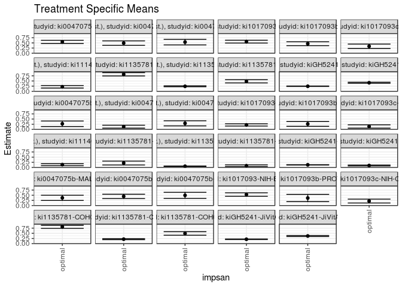

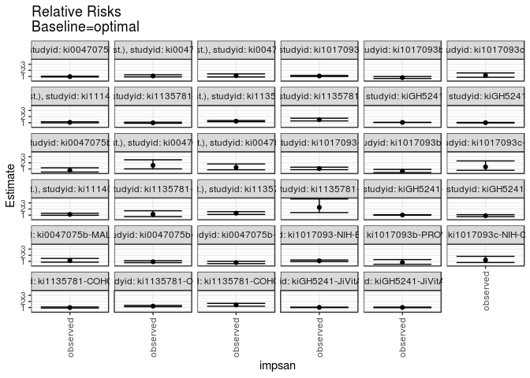

## Results Table

### Parameter: TSM

| agecat | studyid | country | intervention_level | baseline_level | estimate | ci_lower | ci_upper |
| --- | --- | --- | --- | --- | --- | --- | --- |
| 0-24 months (no birth st.) | ki0047075b-MAL-ED | BANGLADESH | optimal | NA | 0.5490310 | 0.4732789 | 0.6247831 |
| 0-24 months (no birth st.) | ki0047075b-MAL-ED | INDIA | optimal | NA | 0.4905270 | 0.3851325 | 0.5959215 |
| 0-24 months (no birth st.) | ki0047075b-MAL-ED | PERU | optimal | NA | 0.5385335 | 0.4028119 | 0.6742552 |
| 0-24 months (no birth st.) | ki1017093-NIH-Birth | BANGLADESH | optimal | NA | 0.5606227 | 0.4934550 | 0.6277904 |
| 0-24 months (no birth st.) | ki1017093b-PROVIDE | BANGLADESH | optimal | NA | 0.4605803 | 0.3635747 | 0.5575860 |
| 0-24 months (no birth st.) | ki1017093c-NIH-Crypto | BANGLADESH | optimal | NA | 0.3359853 | 0.2277421 | 0.4442285 |
| 0-24 months (no birth st.) | ki1114097-CONTENT | PERU | optimal | NA | 0.2164583 | 0.1567084 | 0.2762082 |
| 0-24 months (no birth st.) | ki1135781-COHORTS | GUATEMALA | optimal | NA | 0.8239787 | 0.7440408 | 0.9039166 |
| 0-24 months (no birth st.) | ki1135781-COHORTS | INDIA | optimal | NA | 0.2417969 | 0.2205202 | 0.2630737 |
| 0-24 months (no birth st.) | ki1135781-COHORTS | PHILIPPINES | optimal | NA | 0.4845108 | 0.4075013 | 0.5615202 |
| 0-24 months (no birth st.) | kiGH5241-JiVitA-3 | BANGLADESH | optimal | NA | 0.2438891 | 0.2348137 | 0.2529646 |
| 0-24 months (no birth st.) | kiGH5241-JiVitA-4 | BANGLADESH | optimal | NA | 0.4130997 | 0.3872277 | 0.4389716 |
| 0-6 months (no birth st.) | ki0047075b-MAL-ED | BANGLADESH | optimal | NA | 0.2722012 | 0.1386329 | 0.4057695 |
| 0-6 months (no birth st.) | ki0047075b-MAL-ED | INDIA | optimal | NA | 0.1299553 | 0.0591172 | 0.2007934 |
| 0-6 months (no birth st.) | ki0047075b-MAL-ED | PERU | optimal | NA | 0.2930486 | 0.1691012 | 0.4169960 |
| 0-6 months (no birth st.) | ki1017093-NIH-Birth | BANGLADESH | optimal | NA | 0.2161920 | 0.1624818 | 0.2699021 |
| 0-6 months (no birth st.) | ki1017093b-PROVIDE | BANGLADESH | optimal | NA | 0.2639720 | 0.1478275 | 0.3801164 |
| 0-6 months (no birth st.) | ki1017093c-NIH-Crypto | BANGLADESH | optimal | NA | 0.1398295 | 0.0593032 | 0.2203557 |
| 0-6 months (no birth st.) | ki1114097-CONTENT | PERU | optimal | NA | 0.1359265 | 0.0862436 | 0.1856094 |
| 0-6 months (no birth st.) | ki1135781-COHORTS | GUATEMALA | optimal | NA | 0.2146403 | 0.1213386 | 0.3079421 |
| 0-6 months (no birth st.) | ki1135781-COHORTS | INDIA | optimal | NA | 0.0594196 | 0.0474638 | 0.0713754 |
| 0-6 months (no birth st.) | ki1135781-COHORTS | PHILIPPINES | optimal | NA | 0.0849381 | 0.0429613 | 0.1269149 |
| 0-6 months (no birth st.) | kiGH5241-JiVitA-3 | BANGLADESH | optimal | NA | 0.1280323 | 0.1214305 | 0.1346341 |
| 0-6 months (no birth st.) | kiGH5241-JiVitA-4 | BANGLADESH | optimal | NA | 0.0950560 | 0.0735815 | 0.1165306 |
| 6-24 months | ki0047075b-MAL-ED | BANGLADESH | optimal | NA | 0.3734240 | 0.2469333 | 0.4999148 |
| 6-24 months | ki0047075b-MAL-ED | INDIA | optimal | NA | 0.4443806 | 0.3395172 | 0.5492441 |
| 6-24 months | ki0047075b-MAL-ED | PERU | optimal | NA | 0.4953525 | 0.3479765 | 0.6427286 |
| 6-24 months | ki1017093-NIH-Birth | BANGLADESH | optimal | NA | 0.5319745 | 0.4483563 | 0.6155927 |
| 6-24 months | ki1017093b-PROVIDE | BANGLADESH | optimal | NA | 0.3642087 | 0.1903919 | 0.5380254 |
| 6-24 months | ki1017093c-NIH-Crypto | BANGLADESH | optimal | NA | 0.2174668 | 0.1233025 | 0.3116311 |
| 6-24 months | ki1135781-COHORTS | GUATEMALA | optimal | NA | 0.8152113 | 0.7404004 | 0.8900222 |
| 6-24 months | ki1135781-COHORTS | INDIA | optimal | NA | 0.2155588 | 0.1937057 | 0.2374119 |
| 6-24 months | ki1135781-COHORTS | PHILIPPINES | optimal | NA | 0.4934708 | 0.4080921 | 0.5788495 |
| 6-24 months | kiGH5241-JiVitA-3 | BANGLADESH | optimal | NA | 0.2113808 | 0.1993570 | 0.2234045 |
| 6-24 months | kiGH5241-JiVitA-4 | BANGLADESH | optimal | NA | 0.3701718 | 0.3452050 | 0.3951386 |

### Parameter: E(Y)

| agecat | studyid | country | intervention_level | baseline_level | estimate | ci_lower | ci_upper |
| --- | --- | --- | --- | --- | --- | --- | --- |
| 0-24 months (no birth st.) | ki0047075b-MAL-ED | BANGLADESH | observed | NA | 0.5369458 | 0.4681830 | 0.6057086 |
| 0-24 months (no birth st.) | ki0047075b-MAL-ED | INDIA | observed | NA | 0.5333333 | 0.4631313 | 0.6035354 |
| 0-24 months (no birth st.) | ki0047075b-MAL-ED | PERU | observed | NA | 0.6147186 | 0.5518243 | 0.6776129 |
| 0-24 months (no birth st.) | ki1017093-NIH-Birth | BANGLADESH | observed | NA | 0.6018868 | 0.5601729 | 0.6436007 |
| 0-24 months (no birth st.) | ki1017093b-PROVIDE | BANGLADESH | observed | NA | 0.3750000 | 0.3372263 | 0.4127737 |
| 0-24 months (no birth st.) | ki1017093c-NIH-Crypto | BANGLADESH | observed | NA | 0.3919129 | 0.3541506 | 0.4296752 |
| 0-24 months (no birth st.) | ki1114097-CONTENT | PERU | observed | NA | 0.2284264 | 0.1696529 | 0.2871999 |
| 0-24 months (no birth st.) | ki1135781-COHORTS | GUATEMALA | observed | NA | 0.8110236 | 0.7805500 | 0.8414972 |
| 0-24 months (no birth st.) | ki1135781-COHORTS | INDIA | observed | NA | 0.3013786 | 0.2882798 | 0.3144773 |
| 0-24 months (no birth st.) | ki1135781-COHORTS | PHILIPPINES | observed | NA | 0.7228700 | 0.6965868 | 0.7491531 |
| 0-24 months (no birth st.) | kiGH5241-JiVitA-3 | BANGLADESH | observed | NA | 0.2536189 | 0.2458286 | 0.2614092 |
| 0-24 months (no birth st.) | kiGH5241-JiVitA-4 | BANGLADESH | observed | NA | 0.4144516 | 0.3962595 | 0.4326437 |
| 0-6 months (no birth st.) | ki0047075b-MAL-ED | BANGLADESH | observed | NA | 0.2068966 | 0.1510349 | 0.2627582 |
| 0-6 months (no birth st.) | ki0047075b-MAL-ED | INDIA | observed | NA | 0.2051282 | 0.1483073 | 0.2619492 |
| 0-6 months (no birth st.) | ki0047075b-MAL-ED | PERU | observed | NA | 0.3636364 | 0.3014678 | 0.4258049 |
| 0-6 months (no birth st.) | ki1017093-NIH-Birth | BANGLADESH | observed | NA | 0.2283019 | 0.1925336 | 0.2640702 |
| 0-6 months (no birth st.) | ki1017093b-PROVIDE | BANGLADESH | observed | NA | 0.1598101 | 0.1312195 | 0.1884008 |
| 0-6 months (no birth st.) | ki1017093c-NIH-Crypto | BANGLADESH | observed | NA | 0.1866252 | 0.1564874 | 0.2167630 |
| 0-6 months (no birth st.) | ki1114097-CONTENT | PERU | observed | NA | 0.1522843 | 0.1019837 | 0.2025848 |
| 0-6 months (no birth st.) | ki1135781-COHORTS | GUATEMALA | observed | NA | 0.2442478 | 0.2087898 | 0.2797057 |
| 0-6 months (no birth st.) | ki1135781-COHORTS | INDIA | observed | NA | 0.0783541 | 0.0705612 | 0.0861470 |
| 0-6 months (no birth st.) | ki1135781-COHORTS | PHILIPPINES | observed | NA | 0.1928251 | 0.1696580 | 0.2159922 |
| 0-6 months (no birth st.) | kiGH5241-JiVitA-3 | BANGLADESH | observed | NA | 0.1311885 | 0.1255590 | 0.1368180 |
| 0-6 months (no birth st.) | kiGH5241-JiVitA-4 | BANGLADESH | observed | NA | 0.0854560 | 0.0740923 | 0.0968198 |
| 6-24 months | ki0047075b-MAL-ED | BANGLADESH | observed | NA | 0.4213836 | 0.3443902 | 0.4983771 |
| 6-24 months | ki0047075b-MAL-ED | INDIA | observed | NA | 0.4129032 | 0.3351414 | 0.4906651 |
| 6-24 months | ki0047075b-MAL-ED | PERU | observed | NA | 0.3945578 | 0.3152779 | 0.4738378 |
| 6-24 months | ki1017093-NIH-Birth | BANGLADESH | observed | NA | 0.5739130 | 0.5216565 | 0.6261696 |
| 6-24 months | ki1017093b-PROVIDE | BANGLADESH | observed | NA | 0.2989011 | 0.2567922 | 0.3410100 |
| 6-24 months | ki1017093c-NIH-Crypto | BANGLADESH | observed | NA | 0.2640000 | 0.2253243 | 0.3026757 |
| 6-24 months | ki1135781-COHORTS | GUATEMALA | observed | NA | 0.8162939 | 0.7859345 | 0.8466533 |
| 6-24 months | ki1135781-COHORTS | INDIA | observed | NA | 0.2666991 | 0.2531888 | 0.2802093 |
| 6-24 months | ki1135781-COHORTS | PHILIPPINES | observed | NA | 0.7086331 | 0.6777759 | 0.7394903 |
| 6-24 months | kiGH5241-JiVitA-3 | BANGLADESH | observed | NA | 0.2173417 | 0.2079638 | 0.2267196 |
| 6-24 months | kiGH5241-JiVitA-4 | BANGLADESH | observed | NA | 0.3784303 | 0.3598372 | 0.3970234 |

### Parameter: RR

| agecat | studyid | country | intervention_level | baseline_level | estimate | ci_lower | ci_upper |
| --- | --- | --- | --- | --- | --- | --- | --- |
| 0-24 months (no birth st.) | ki0047075b-MAL-ED | BANGLADESH | observed | optimal | 0.9779881 | 0.9193367 | 1.0403813 |
| 0-24 months (no birth st.) | ki0047075b-MAL-ED | INDIA | observed | optimal | 1.0872659 | 0.9280841 | 1.2737501 |
| 0-24 months (no birth st.) | ki0047075b-MAL-ED | PERU | observed | optimal | 1.1414676 | 0.9168579 | 1.4211018 |
| 0-24 months (no birth st.) | ki1017093-NIH-Birth | BANGLADESH | observed | optimal | 1.0736041 | 0.9797443 | 1.1764557 |
| 0-24 months (no birth st.) | ki1017093b-PROVIDE | BANGLADESH | observed | optimal | 0.8141902 | 0.6701419 | 0.9892020 |
| 0-24 months (no birth st.) | ki1017093c-NIH-Crypto | BANGLADESH | observed | optimal | 1.1664585 | 0.8605308 | 1.5811467 |
| 0-24 months (no birth st.) | ki1114097-CONTENT | PERU | observed | optimal | 1.0552905 | 0.9670529 | 1.1515792 |
| 0-24 months (no birth st.) | ki1135781-COHORTS | GUATEMALA | observed | optimal | 0.9842774 | 0.8980277 | 1.0788109 |
| 0-24 months (no birth st.) | ki1135781-COHORTS | INDIA | observed | optimal | 1.2464119 | 1.1568927 | 1.3428580 |
| 0-24 months (no birth st.) | ki1135781-COHORTS | PHILIPPINES | observed | optimal | 1.4919585 | 1.2874796 | 1.7289129 |
| 0-24 months (no birth st.) | kiGH5241-JiVitA-3 | BANGLADESH | observed | optimal | 1.0398942 | 1.0186466 | 1.0615850 |
| 0-24 months (no birth st.) | kiGH5241-JiVitA-4 | BANGLADESH | observed | optimal | 1.0032727 | 0.9621624 | 1.0461395 |
| 0-6 months (no birth st.) | ki0047075b-MAL-ED | BANGLADESH | observed | optimal | 0.7600868 | 0.4887562 | 1.1820455 |
| 0-6 months (no birth st.) | ki0047075b-MAL-ED | INDIA | observed | optimal | 1.5784523 | 1.0003499 | 2.4906402 |
| 0-6 months (no birth st.) | ki0047075b-MAL-ED | PERU | observed | optimal | 1.2408739 | 0.8514784 | 1.8083468 |
| 0-6 months (no birth st.) | ki1017093-NIH-Birth | BANGLADESH | observed | optimal | 1.0560146 | 0.8703007 | 1.2813582 |
| 0-6 months (no birth st.) | ki1017093b-PROVIDE | BANGLADESH | observed | optimal | 0.6054057 | 0.3998566 | 0.9166188 |
| 0-6 months (no birth st.) | ki1017093c-NIH-Crypto | BANGLADESH | observed | optimal | 1.3346628 | 0.7719070 | 2.3076935 |
| 0-6 months (no birth st.) | ki1114097-CONTENT | PERU | observed | optimal | 1.1203428 | 0.9716367 | 1.2918079 |
| 0-6 months (no birth st.) | ki1135781-COHORTS | GUATEMALA | observed | optimal | 1.1379398 | 0.7546817 | 1.7158320 |
| 0-6 months (no birth st.) | ki1135781-COHORTS | INDIA | observed | optimal | 1.3186577 | 1.1069875 | 1.5708019 |
| 0-6 months (no birth st.) | ki1135781-COHORTS | PHILIPPINES | observed | optimal | 2.2701838 | 1.4121193 | 3.6496453 |
| 0-6 months (no birth st.) | kiGH5241-JiVitA-3 | BANGLADESH | observed | optimal | 1.0246516 | 0.9914683 | 1.0589456 |
| 0-6 months (no birth st.) | kiGH5241-JiVitA-4 | BANGLADESH | observed | optimal | 0.8990070 | 0.7524017 | 1.0741783 |
| 6-24 months | ki0047075b-MAL-ED | BANGLADESH | observed | optimal | 1.1284320 | 0.8618520 | 1.4774680 |
| 6-24 months | ki0047075b-MAL-ED | INDIA | observed | optimal | 0.9291656 | 0.7822191 | 1.1037173 |
| 6-24 months | ki0047075b-MAL-ED | PERU | observed | optimal | 0.7965193 | 0.6253176 | 1.0145932 |
| 6-24 months | ki1017093-NIH-Birth | BANGLADESH | observed | optimal | 1.0788356 | 0.9563306 | 1.2170334 |
| 6-24 months | ki1017093b-PROVIDE | BANGLADESH | observed | optimal | 0.8206864 | 0.5233404 | 1.2869752 |
| 6-24 months | ki1017093c-NIH-Crypto | BANGLADESH | observed | optimal | 1.2139784 | 0.8080322 | 1.8238675 |
| 6-24 months | ki1135781-COHORTS | GUATEMALA | observed | optimal | 1.0013280 | 0.9191381 | 1.0908674 |
| 6-24 months | ki1135781-COHORTS | INDIA | observed | optimal | 1.2372448 | 1.1354913 | 1.3481166 |
| 6-24 months | ki1135781-COHORTS | PHILIPPINES | observed | optimal | 1.4360183 | 1.2246728 | 1.6838363 |
| 6-24 months | kiGH5241-JiVitA-3 | BANGLADESH | observed | optimal | 1.0282000 | 0.9916475 | 1.0660998 |
| 6-24 months | kiGH5241-JiVitA-4 | BANGLADESH | observed | optimal | 1.0223099 | 0.9745455 | 1.0724153 |

### Parameter: PAR

| agecat | studyid | country | intervention_level | baseline_level | estimate | ci_lower | ci_upper |
| --- | --- | --- | --- | --- | --- | --- | --- |
| 0-24 months (no birth st.) | ki0047075b-MAL-ED | BANGLADESH | optimal | NA | -0.0120852 | -0.0459592 | 0.0217888 |
| 0-24 months (no birth st.) | ki0047075b-MAL-ED | INDIA | optimal | NA | 0.0428063 | -0.0345365 | 0.1201491 |
| 0-24 months (no birth st.) | ki0047075b-MAL-ED | PERU | optimal | NA | 0.0761851 | -0.0411979 | 0.1935680 |
| 0-24 months (no birth st.) | ki1017093-NIH-Birth | BANGLADESH | optimal | NA | 0.0412641 | -0.0098374 | 0.0923656 |
| 0-24 months (no birth st.) | ki1017093b-PROVIDE | BANGLADESH | optimal | NA | -0.0855803 | -0.1748584 | 0.0036977 |
| 0-24 months (no birth st.) | ki1017093c-NIH-Crypto | BANGLADESH | optimal | NA | 0.0559276 | -0.0462315 | 0.1580867 |
| 0-24 months (no birth st.) | ki1114097-CONTENT | PERU | optimal | NA | 0.0119681 | -0.0070210 | 0.0309572 |
| 0-24 months (no birth st.) | ki1135781-COHORTS | GUATEMALA | optimal | NA | -0.0129551 | -0.0884922 | 0.0625820 |
| 0-24 months (no birth st.) | ki1135781-COHORTS | INDIA | optimal | NA | 0.0595816 | 0.0414938 | 0.0776695 |
| 0-24 months (no birth st.) | ki1135781-COHORTS | PHILIPPINES | optimal | NA | 0.2383592 | 0.1682156 | 0.3085028 |
| 0-24 months (no birth st.) | kiGH5241-JiVitA-3 | BANGLADESH | optimal | NA | 0.0097298 | 0.0046896 | 0.0147700 |
| 0-24 months (no birth st.) | kiGH5241-JiVitA-4 | BANGLADESH | optimal | NA | 0.0013519 | -0.0159280 | 0.0186319 |
| 0-6 months (no birth st.) | ki0047075b-MAL-ED | BANGLADESH | optimal | NA | -0.0653047 | -0.1847876 | 0.0541783 |
| 0-6 months (no birth st.) | ki0047075b-MAL-ED | INDIA | optimal | NA | 0.0751729 | 0.0133194 | 0.1370264 |
| 0-6 months (no birth st.) | ki0047075b-MAL-ED | PERU | optimal | NA | 0.0705878 | -0.0396985 | 0.1808741 |
| 0-6 months (no birth st.) | ki1017093-NIH-Birth | BANGLADESH | optimal | NA | 0.0121099 | -0.0297560 | 0.0539758 |
| 0-6 months (no birth st.) | ki1017093b-PROVIDE | BANGLADESH | optimal | NA | -0.1041618 | -0.2139263 | 0.0056026 |
| 0-6 months (no birth st.) | ki1017093c-NIH-Crypto | BANGLADESH | optimal | NA | 0.0467957 | -0.0298984 | 0.1234898 |
| 0-6 months (no birth st.) | ki1114097-CONTENT | PERU | optimal | NA | 0.0163578 | -0.0035045 | 0.0362201 |
| 0-6 months (no birth st.) | ki1135781-COHORTS | GUATEMALA | optimal | NA | 0.0296074 | -0.0586735 | 0.1178884 |
| 0-6 months (no birth st.) | ki1135781-COHORTS | INDIA | optimal | NA | 0.0189345 | 0.0083674 | 0.0295016 |
| 0-6 months (no birth st.) | ki1135781-COHORTS | PHILIPPINES | optimal | NA | 0.1078870 | 0.0660073 | 0.1497667 |
| 0-6 months (no birth st.) | kiGH5241-JiVitA-3 | BANGLADESH | optimal | NA | 0.0031562 | -0.0010737 | 0.0073861 |
| 0-6 months (no birth st.) | kiGH5241-JiVitA-4 | BANGLADESH | optimal | NA | -0.0096000 | -0.0266147 | 0.0074147 |
| 6-24 months | ki0047075b-MAL-ED | BANGLADESH | optimal | NA | 0.0479596 | -0.0522830 | 0.1482022 |
| 6-24 months | ki0047075b-MAL-ED | INDIA | optimal | NA | -0.0314774 | -0.1073444 | 0.0443896 |
| 6-24 months | ki0047075b-MAL-ED | PERU | optimal | NA | -0.1007947 | -0.2202064 | 0.0186170 |
| 6-24 months | ki1017093-NIH-Birth | BANGLADESH | optimal | NA | 0.0419385 | -0.0219674 | 0.1058444 |
| 6-24 months | ki1017093b-PROVIDE | BANGLADESH | optimal | NA | -0.0653076 | -0.2298243 | 0.0992091 |
| 6-24 months | ki1017093c-NIH-Crypto | BANGLADESH | optimal | NA | 0.0465332 | -0.0422309 | 0.1352973 |
| 6-24 months | ki1135781-COHORTS | GUATEMALA | optimal | NA | 0.0010826 | -0.0687389 | 0.0709041 |
| 6-24 months | ki1135781-COHORTS | INDIA | optimal | NA | 0.0511402 | 0.0325625 | 0.0697179 |
| 6-24 months | ki1135781-COHORTS | PHILIPPINES | optimal | NA | 0.2151623 | 0.1378735 | 0.2924511 |
| 6-24 months | kiGH5241-JiVitA-3 | BANGLADESH | optimal | NA | 0.0059609 | -0.0016896 | 0.0136114 |
| 6-24 months | kiGH5241-JiVitA-4 | BANGLADESH | optimal | NA | 0.0082585 | -0.0094717 | 0.0259887 |

### Parameter: PAF

| agecat | studyid | country | intervention_level | baseline_level | estimate | ci_lower | ci_upper |
| --- | --- | --- | --- | --- | --- | --- | --- |
| 0-24 months (no birth st.) | ki0047075b-MAL-ED | BANGLADESH | optimal | NA | -0.0225073 | -0.0877408 | 0.0388140 |
| 0-24 months (no birth st.) | ki0047075b-MAL-ED | INDIA | optimal | NA | 0.0802618 | -0.0774886 | 0.2149166 |
| 0-24 months (no birth st.) | ki0047075b-MAL-ED | PERU | optimal | NA | 0.1239349 | -0.0906816 | 0.2963207 |
| 0-24 months (no birth st.) | ki1017093-NIH-Birth | BANGLADESH | optimal | NA | 0.0685579 | -0.0206745 | 0.1499892 |
| 0-24 months (no birth st.) | ki1017093b-PROVIDE | BANGLADESH | optimal | NA | -0.2282143 | -0.4922214 | -0.0109159 |
| 0-24 months (no birth st.) | ki1017093c-NIH-Crypto | BANGLADESH | optimal | NA | 0.1427042 | -0.1620734 | 0.3675476 |
| 0-24 months (no birth st.) | ki1114097-CONTENT | PERU | optimal | NA | 0.0523936 | -0.0340696 | 0.1316272 |
| 0-24 months (no birth st.) | ki1135781-COHORTS | GUATEMALA | optimal | NA | -0.0159737 | -0.1135514 | 0.0730535 |
| 0-24 months (no birth st.) | ki1135781-COHORTS | INDIA | optimal | NA | 0.1976970 | 0.1356156 | 0.2553197 |
| 0-24 months (no birth st.) | ki1135781-COHORTS | PHILIPPINES | optimal | NA | 0.3297401 | 0.2232887 | 0.4216019 |
| 0-24 months (no birth st.) | kiGH5241-JiVitA-3 | BANGLADESH | optimal | NA | 0.0383637 | 0.0183052 | 0.0580123 |
| 0-24 months (no birth st.) | kiGH5241-JiVitA-4 | BANGLADESH | optimal | NA | 0.0032620 | -0.0393256 | 0.0441045 |
| 0-6 months (no birth st.) | ki0047075b-MAL-ED | BANGLADESH | optimal | NA | -0.3156392 | -1.0460101 | 0.1540089 |
| 0-6 months (no birth st.) | ki0047075b-MAL-ED | INDIA | optimal | NA | 0.3664680 | 0.0003497 | 0.5984968 |
| 0-6 months (no birth st.) | ki0047075b-MAL-ED | PERU | optimal | NA | 0.1941164 | -0.1744280 | 0.4470087 |
| 0-6 months (no birth st.) | ki1017093-NIH-Birth | BANGLADESH | optimal | NA | 0.0530434 | -0.1490282 | 0.2195781 |
| 0-6 months (no birth st.) | ki1017093b-PROVIDE | BANGLADESH | optimal | NA | -0.6517849 | -1.5008966 | -0.0909661 |
| 0-6 months (no birth st.) | ki1017093c-NIH-Crypto | BANGLADESH | optimal | NA | 0.2507471 | -0.2954929 | 0.5666669 |
| 0-6 months (no birth st.) | ki1114097-CONTENT | PERU | optimal | NA | 0.1074161 | -0.0291913 | 0.2258911 |
| 0-6 months (no birth st.) | ki1135781-COHORTS | GUATEMALA | optimal | NA | 0.1212189 | -0.3250620 | 0.4171924 |
| 0-6 months (no birth st.) | ki1135781-COHORTS | INDIA | optimal | NA | 0.2416531 | 0.0966474 | 0.3633825 |
| 0-6 months (no birth st.) | ki1135781-COHORTS | PHILIPPINES | optimal | NA | 0.5595070 | 0.2918445 | 0.7260008 |
| 0-6 months (no birth st.) | kiGH5241-JiVitA-3 | BANGLADESH | optimal | NA | 0.0240586 | -0.0086051 | 0.0556644 |
| 0-6 months (no birth st.) | kiGH5241-JiVitA-4 | BANGLADESH | optimal | NA | -0.1123384 | -0.3290773 | 0.0690558 |
| 6-24 months | ki0047075b-MAL-ED | BANGLADESH | optimal | NA | 0.1138146 | -0.1602920 | 0.3231664 |
| 6-24 months | ki0047075b-MAL-ED | INDIA | optimal | NA | -0.0762344 | -0.2784142 | 0.0939709 |
| 6-24 months | ki0047075b-MAL-ED | PERU | optimal | NA | -0.2554624 | -0.5991875 | 0.0143833 |
| 6-24 months | ki1017093-NIH-Birth | BANGLADESH | optimal | NA | 0.0730747 | -0.0456635 | 0.1783299 |
| 6-24 months | ki1017093b-PROVIDE | BANGLADESH | optimal | NA | -0.2184922 | -0.9108021 | 0.2229842 |
| 6-24 months | ki1017093c-NIH-Crypto | BANGLADESH | optimal | NA | 0.1762621 | -0.2375745 | 0.4517145 |
| 6-24 months | ki1135781-COHORTS | GUATEMALA | optimal | NA | 0.0013262 | -0.0879758 | 0.0832983 |
| 6-24 months | ki1135781-COHORTS | INDIA | optimal | NA | 0.1917525 | 0.1193239 | 0.2582244 |
| 6-24 months | ki1135781-COHORTS | PHILIPPINES | optimal | NA | 0.3036301 | 0.1834554 | 0.4061181 |
| 6-24 months | kiGH5241-JiVitA-3 | BANGLADESH | optimal | NA | 0.0274266 | -0.0084229 | 0.0620015 |
| 6-24 months | kiGH5241-JiVitA-4 | BANGLADESH | optimal | NA | 0.0218230 | -0.0261193 | 0.0675254 |